# Meta Analysis Psilocybin Cognition: Reaction Time

2024-07-05

authors: Parsa Yousefi, Ralph Rippe

# setup

```r
 knitr::opts_knit$set(root.dir = "C:/Users/prsyu/OneDrive/Bidlung/University/M.S. Leiden University/M.S. Neuroscience (Research)/Internship Groningen/GitHub_Multiverse_meta/MetaAnalysis-Psilo-Cognition/Code")
 knitr::opts_chunk$set(echo = TRUE, fig.retina=2, fig.show = 'hold', fig.align = 'center', fig.width = 7, fig.height = 10, warning = FALSE)

# install.packages("readxl")
 #install.packages("rmarkdown")
# install.packages("metafor")
# install.packages("meta")
# install.packages("dplyr")
# install.packages("gridExtra")
# install.packages("caret")
# install.packages("forrest")
# install.packages("tidyverse")
# install.packages("mvmeta")
# install.packages("plotly")
# install.packages("RColorBrewer")
# if (!require("remotes")) {
#     install.packages("remotes")
# }
#install.packages("xfun")
#install.packages("zcurve")
library("here")
library("tidyverse")
library("caret")
library("rmarkdown")
library("stringr")
library("readxl")
library("metafor")
library("meta")
library("dplyr")
library("ggplot2")
library("gridExtra")
library("plotly")
library("RColorBrewer")
library("rmarkdown")
library("knitr")
library("zcurve")

source(here("Code","functions.r"))

# Define data file
datafile <- here("Overview_Studies.xlsx")
```

# Load Data

```r
Read_Prepare <- function(datafile) {
    # Read the overview sheet
    data <- as.data.frame(read_excel(datafile, sheet = "Overview"))

    # Define columns to select using all_of() for safe selection
    cols_to_select <- c(
        "ID", "ES_ID", "CognitiveFunction", "N_final", "ES_final_RT", "ES_final_ACC",
        "ES_final_other", "Timepoint", "PlotLabel", "DoseLabel", "EF_sensitivity"
    )

    # Select the columns using all_of() to avoid tidyselect warning
    data <- select(data, all_of(cols_to_select))

    # Preprocessing: Assign numeric IDs and convert numeric columns

    numeric_cols <- c("N_final", "ES_final_RT", "ES_final_ACC", "ES_final_other", "Timepoint", "EF_sensitivity")
    data[numeric_cols] <- lapply(data[numeric_cols], function(x) {
        as.numeric(as.character(x))
    })

    # Convert all other columns that are not in numeric_cols to factors
    non_numeric_cols <- setdiff(names(data), numeric_cols)
    data[non_numeric_cols] <- lapply(data[non_numeric_cols], as.factor)

    # Handle potential NA introduction by coercion
    if (any(sapply(data[numeric_cols], is.na))) {
        warning("NA values were introduced by coercion.")
    }

    # Clean up text data
    text_cols <- setdiff(names(data), numeric_cols)
    data[text_cols] <- lapply(data[text_cols], gsub, pattern = "\r\n|\r|\n", replacement = "")

    # Filter data by dose categories
    data_micro <- filter(data, DoseLabel == "Micro")
    data_low <- filter(data, DoseLabel == "Low")
    data_mid <- filter(data, DoseLabel == "Medium")
    data_high <- filter(data, DoseLabel == "High")

    # Combine all the filtered data back into one dataframe in the correct order
    data_combined <- bind_rows(data_micro, data_low, data_mid, data_high)

    # Ensure all necessary dose data frames are correctly combined
    if (!is.null(data_combined) && nrow(data_combined) == nrow(data)) {
        # Assign dosage categories
        data_combined$dosage_cat_all <- c(
            rep(0, nrow(data_micro)),
            rep(1, nrow(data_low)),
            rep(2, nrow(data_mid)),
            rep(3, nrow(data_high))
        )
        data_combined$dosage_cat_micro <- c(
            rep(0, nrow(data_micro)),
            rep(1, nrow(data_low) + nrow(data_mid) + nrow(data_high))
        )
        data_combined$dosage_cat_microlow_vs_midhigh <- c(
            rep(1, nrow(data_low) + nrow(data_micro)),
            rep(2, nrow(data_mid) + nrow(data_high))
        )
    } else {
        stop("Row counts do not match after combining data subsets. Check the filtering criteria.")
    }

    return(data_combined)
}


data <- Read_Prepare(datafile)
head(data)
```

```
##   ID ES_ID      CognitiveFunction N_final ES_final_RT ES_final_ACC
## 1  3    16    Conflict monitoring      34  0.51492630 -0.107113300
## 2  3    17             Inhibition      34          NA -0.009562515
## 3  3    18              Attention      34 -0.04110792  0.298592600
## 4  3    19 Cognitive  Flexibility      34  0.75811230           NA
## 5  6    21              Attention       8          NA  0.404061000
## 6 11    31             Inhibition      40          NA -0.033099040
##   ES_final_other Timepoint               PlotLabel DoseLabel EF_sensitivity
## 1             NA       180   Cavanna et al. (2022)     Micro              1
## 2             NA       150   Cavanna et al. (2022)     Micro              1
## 3             NA       180   Cavanna et al. (2022)     Micro              1
## 4             NA        60   Cavanna et al. (2022)     Micro              2
## 5     -0.2855162       140     Hasler et al (2004)     Micro              2
## 6     -0.1800000        90 Marschall et al. (2022)     Micro              1
##   dosage_cat_all dosage_cat_micro dosage_cat_microlow_vs_midhigh
## 1              0                0                              1
## 2              0                0                              1
## 3              0                0                              1
## 4              0                0                              1
## 5              0                0                              1
## 6              0                0                              1
```

```r
# add the variance of the Cohen's d to the dataset
# https://stats.stackexchange.com/questions/144084/variance-of-cohens-d-statistic
# https://stats.stackexchange.com/questions/495015/what-is-the-formula-for-the-standard-error-of-cohens-d
AddCohensDVariance <- function(data) {
    # Ensure 'data' is a data frame
    if (!is.data.frame(data)) {
        stop("The 'data' argument must be a data frame.")
    }

    # Initialize variance columns with NA
    data$ES_var_RT <- NA
    data$ES_var_ACC <- NA
    data$ES_var_other <- NA

    # Define split factor
    splitfactor <- 2

    # Loop through each row to calculate variances
    for (i in seq_len(nrow(data))) {
        N_sum <- data$N_final[i]
        N_prod <- (data$N_final[i] / splitfactor) * (data$N_final[i] / splitfactor)

        # Calculating variance for each effect size
        data$ES_var_RT[i] <- (N_sum / N_prod) + (data$ES_final_RT[i]^2 / (2 * N_sum))
        data$ES_var_ACC[i] <- (N_sum / N_prod) + (data$ES_final_ACC[i]^2 / (2 * N_sum))
        data$ES_var_other[i] <- (N_sum / N_prod) + (data$ES_final_other[i]^2 / (2 * N_sum))
    }

    return(data)
}

data <- AddCohensDVariance(data)
```

# select data

```r
# Define the columns to select
cols_to_select <- c(
    "ID", "ES_ID", "CognitiveFunction", "N_final", "ES_final_RT",
    "ES_var_RT", "Timepoint", "PlotLabel", "DoseLabel", "EF_sensitivity", "dosage_cat_all", "dosage_cat_micro", "dosage_cat_microlow_vs_midhigh"
)

# Select the columns and filter rows where ES_final_RT is not NA
data_RT <- subset(data, select = cols_to_select, !is.na(ES_final_RT))
data_RT$CognitiveFunction <- as.factor(data_RT$CognitiveFunction)
data_RT$DoseLabel <- as.factor(data_RT$DoseLabel)
data_RT$EF_sensitivity <- as.factor(data_RT$EF_sensitivity)
data_RT$dosage_cat_all <- as.factor(data_RT$dosage_cat_all)
data_RT$ES_ID <- as.factor(data_RT$ES_ID)
data_RT$ID <- as.factor(data_RT$ID)

# Number of entries for RT measure
n_rows <- nrow(data_RT)
n_unique_ids <- length(unique(data_RT$ID))


# Print the results
cat("Number of entries for RT measure:", n_rows, "\n")
```

```
## Number of entries for RT measure: 15
```

```r
cat("Number of unique IDs:", n_unique_ids, "\n")
```

```
## Number of unique IDs: 6
```

```r
head(data_RT)
```

```
##    ID ES_ID      CognitiveFunction N_final ES_final_RT ES_var_RT Timepoint
## 1   3    16    Conflict monitoring      34  0.51492630 0.1215463       180
## 3   3    18              Attention      34 -0.04110792 0.1176719       180
## 4   3    19 Cognitive  Flexibility      34  0.75811230 0.1260990        60
## 7   1     1         Working Memory      19  1.25000000 0.2516447       180
## 8   1     2    Conflict monitoring      20  1.44400000 0.2521284       240
## 14  5    20              Attention      16  0.46935300 0.2568841        85
##                           PlotLabel DoseLabel EF_sensitivity dosage_cat_all
## 1             Cavanna et al. (2022)     Micro              1              0
## 3             Cavanna et al. (2022)     Micro              1              0
## 4             Cavanna et al. (2022)     Micro              2              0
## 7             Barrett et al. (2017)       Low              1              1
## 8             Barrett et al. (2017)       Low              3              1
## 14 Gouzoulis-Mayfrank et al. (2002)       Low              1              1
##    dosage_cat_micro dosage_cat_microlow_vs_midhigh
## 1                 0                              1
## 3                 0                              1
## 4                 0                              1
## 7                 1                              1
## 8                 1                              1
## 14                1                              1
```

```r
# Define the columns to select
cols_to_select_ACC <- c(
    "ID", "ES_ID", "CognitiveFunction", "N_final", "ES_final_ACC",
    "ES_var_ACC", "Timepoint", "PlotLabel", "DoseLabel", "EF_sensitivity", "dosage_cat_all", "dosage_cat_micro", "dosage_cat_microlow_vs_midhigh"
)

# Select the columns and filter rows where ES_final_ACC is not NA
data_ACC <- subset(data, select = cols_to_select_ACC, !is.na(ES_final_ACC))

data_ACC$CognitiveFunction <- as.factor(data_ACC$CognitiveFunction)
data_ACC$DoseLabel <- as.factor(data_ACC$DoseLabel)
data_ACC$EF_sensitivity <- as.factor(data_ACC$EF_sensitivity)
data_ACC$dosage_cat_all <- as.factor(data_ACC$dosage_cat_all)
data_ACC$ES_ID <- as.factor(data_ACC$ES_ID)
data_ACC$ID <- as.factor(data_ACC$ID)



# Number of entries for ACC measure
n_rows_ACC <- nrow(data_ACC)
n_unique_ids_ACC <- length(unique(data_ACC$ID))


# Print the results
cat("Number of entries for ACC measure:", n_rows_ACC, "\n")
```

```
## Number of entries for ACC measure: 27
```

```r
cat("Number of unique IDs:", n_unique_ids_ACC, "\n")
```

```
## Number of unique IDs: 10
```

```r
head(data_ACC)
```

```
##   ID ES_ID      CognitiveFunction N_final ES_final_ACC ES_var_ACC Timepoint
## 1  3    16    Conflict monitoring      34 -0.107113300  0.1178158       180
## 2  3    17             Inhibition      34 -0.009562515  0.1176484       150
## 3  3    18              Attention      34  0.298592600  0.1189582       180
## 5  6    21              Attention       8  0.404061000  0.5102041       140
## 6 11    31             Inhibition      40 -0.033099040  0.1000137        90
## 9  1     3 Cognitive  Flexibility      14  0.171800000  0.2867684       120
##                 PlotLabel DoseLabel EF_sensitivity dosage_cat_all
## 1   Cavanna et al. (2022)     Micro              1              0
## 2   Cavanna et al. (2022)     Micro              1              0
## 3   Cavanna et al. (2022)     Micro              1              0
## 5     Hasler et al (2004)     Micro              2              0
## 6 Marschall et al. (2022)     Micro              1              0
## 9   Barrett et al. (2017)       Low              3              1
##   dosage_cat_micro dosage_cat_microlow_vs_midhigh
## 1                0                              1
## 2                0                              1
## 3                0                              1
## 5                0                              1
## 6                0                              1
## 9                1                              1
```

# 3.4 Results

# 3.4.1 Reaction Time

```r
calculate_meta <- function(RT = FALSE, ACC = FALSE) {
    library(metafor) # Load the metafor library

    # Select the appropriate dataset
    if (RT) {
        data <- data_RT
        effect_size_col <- "ES_final_RT"
        variance_col <- "ES_var_RT"
    } else if (ACC) {
        data <- data_ACC
        effect_size_col <- "ES_final_ACC"
        variance_col <- "ES_var_ACC"
    } else {
        stop("Either RT or ACC must be set to TRUE.")
    }

    # Order data by ID
    data <- data[order(data$ID), ]

    # Initialize a list to store the results
    model_results <- list()

    # Fit the models

    # Fit the nested model
    model_multi <- rma.mv(
        yi = data[[effect_size_col]],
        V = data[[variance_col]],
        random = ~ 1 | ID / ES_ID,
        data = data,
        test = "t",
        method = "REML",
        slab = data$ES_ID
    )

    # Fit the non-nested model (same random structure without sigma^2 = 0 constraint)
    model_plain <- rma.mv(
        yi = data[[effect_size_col]],
        V = data[[variance_col]],
        random = ~ 1 | ID / ES_ID,
        data = data,
        test = "t",
        method = "REML",
        slab = data$ES_ID,
        sigma2 = c(0, NA)
    )

    # Fit the univariate model
    model_uni <- rma.uni(
        yi = data[[effect_size_col]],
        vi = data[[variance_col]],
        # random = ~ 1 | ID/ES_ID,
        data = data,
        test = "t",
        method = "REML",
        slab = data$ES_ID
    )

    # Perform variance analysis and model comparison
    variance_analysis <- mlm.variance.distribution(model_multi)
    model_comparison <- anova(model_multi, model_plain)

    # Store results in the list
    model_results <- list(
        model_multi = model_multi,
        model_plain = model_plain,
        model_uni = model_uni,
        variance_analysis = variance_analysis,
        model_comparison = model_comparison
    )

    return(model_results)
}
```

nested model:

```r
print(calculate_meta(RT = TRUE)$model_multi)
```

```
##
## Multivariate Meta-Analysis Model (k = 15; method: REML)
##
## Variance Components:
##
##             estim    sqrt  nlvls  fixed    factor
## sigma^2.1  0.2710  0.5206      6     no        ID
## sigma^2.2  0.0147  0.1212     15     no  ID/ES_ID
##
## Test for Heterogeneity:
## Q(df = 14) = 33.5458, p-val = 0.0024
##
## Model Results:
##
## estimate      se    tval  df    pval   ci.lb   ci.ub
##   1.1329  0.2615  4.3327  14  0.0007  0.5721  1.6936  ***
##
## ---
## Signif. codes:  0 '***' 0.001 '**' 0.01 '*' 0.05 '.' 0.1 ' ' 1
```

```r
print(calculate_meta(RT = TRUE)$variance_analysis$ResultsTable)
```

```
##                      Level Variance_Percentage        I2
## 1 Level 1 (Sampling Error)           63.229025        NA
## 2                  Level 2            1.892011  1.892011
## 3                  Level 3           34.878964 34.878964
```

```r
print(calculate_meta(RT = TRUE)$variance_analysis$TotalI2)
```

```
## [1] 36.77097
```

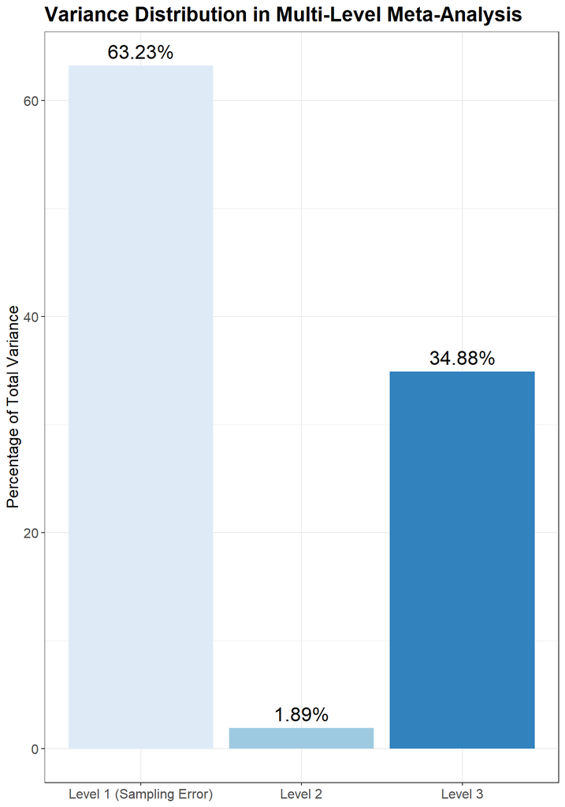

```r
print(calculate_meta(RT = TRUE)$variance_analysis$Plot)
```

non ntested model

```r
print(calculate_meta(RT=TRUE)$model_uni)
```

```
##
## Random-Effects Model (k = 15; tau^2 estimator: REML)
##
## tau^2 (estimated amount of total heterogeneity): 0.2941 (SE = 0.1978)
## tau (square root of estimated tau^2 value):      0.5423
## I^2 (total heterogeneity / total variability):   57.34%
## H^2 (total variability / sampling variability):  2.34
##
## Test for Heterogeneity:
## Q(df = 14) = 33.5458, p-val = 0.0024
##
## Model Results:
##
## estimate      se    tval  df    pval   ci.lb   ci.ub
##   1.2140  0.1876  6.4728  14  <.0001  0.8117  1.6163  ***
##
## ---
## Signif. codes:  0 '***' 0.001 '**' 0.01 '*' 0.05 '.' 0.1 ' ' 1
```

nested vs non nested model

```r
print(calculate_meta(RT = TRUE)$model_comparison)
```

```
##
##         df     AIC     BIC    AICc   logLik    LRT   pval      QE
## Full     3 31.3348 33.2520 33.7348 -12.6674               33.5458
## Reduced  2 34.2742 35.5523 35.3651 -15.1371 4.9394 0.0263 33.5458
```

# 3.4.1.1 Outliers and influential cases RT

```r
library(ggplot2)
library(metafor) # Ensure metafor is loaded for meta-analysis functions

identify_outliers <- function(data_type, multi = FALSE) {
    if (data_type != "RT" && data_type != "ACC") {
        stop("data_type must be 'RT' or 'ACC'.")
    }

    # Select data and set parameters
    if (data_type == "RT") {
        data <- as.data.frame(data_RT)
        effect_size_col <- "ES_final_RT"
        variance_col <- "ES_var_RT"
        plottitle <- "Reaction Time Effect Size Distribution"
    } else if (data_type == "ACC") {
        data <- as.data.frame(data_ACC)
        effect_size_col <- "ES_final_ACC"
        variance_col <- "ES_var_ACC"
        plottitle <- "Accuracy Effect Size Distribution"
    }

    # Perform meta-analysis using calculate_meta function
    meta_results <- calculate_meta(RT = (data_type == "RT"), ACC = (data_type == "ACC"))
    model <- meta_results$model_multi

    # Extracting the confidence intervals from the model
    overall_ci_lb <- coef(summary(model))["intrcpt", "ci.lb"]
    overall_ci_ub <- coef(summary(model))["intrcpt", "ci.ub"]

    # Calculate CI for each observed effect size in the dataset
    data$d <- data[[effect_size_col]]
    data$upperci <- data$d + 1.96 * sqrt(data[[variance_col]])
    data$lowerci <- data$d - 1.96 * sqrt(data[[variance_col]])
    data$outlier <- with(data, upperci < overall_ci_lb | lowerci > overall_ci_ub)

# Set up the color palette
  color_palette <- brewer.pal(3, "Blues")[2:3]
  names(color_palette) <- c("FALSE", "TRUE")

  # Determine the range of effect sizes
  effect_size_range <- range(data$d)

  # Determine the break points for the x-axis
  break_points <- seq(floor(effect_size_range[1] * 4) / 4, ceiling(effect_size_range[2] * 4) / 4, by = 0.25)

  # Plotting the data with outliers highlighted
  plot <- ggplot(data, aes(x = d, colour = outlier, fill = outlier)) +
    geom_histogram(alpha = 0.5, bins = 30) +
    geom_vline(xintercept = coef(model)["intrcpt"], linetype = "dashed", color = "blue") +
    scale_fill_manual(values = color_palette) +
    scale_color_manual(values = color_palette) +
    labs(title = plottitle, x = "Effect Size", y = "Frequency") +
    scale_x_continuous(breaks = break_points) +  # Set the break points for the x-axis
    theme_bw() +
    theme(
      plot.title = element_text(size = 18, face = "bold"),
      axis.title = element_text(size = 14),
      axis.text = element_text(size = 12),
      legend.position = "none"
    )
    # Filter data to remove outliers and re-run meta-analysis if required
    filtered_data <- data[!data$outlier, ]
    if (nrow(filtered_data) > 1) { # Check if there is enough data to re-run the meta-analysis
        model_no_outlier <- rma.mv(
            yi = filtered_data[[effect_size_col]],
            V = filtered_data[[variance_col]],
            random = ~ 1 | ID / ES_ID,
            data = filtered_data,
            method = "REML"
        )
        summary_no_outlier <- summary(model_no_outlier)
    } else {
        summary_no_outlier <- NULL
    }

    # Prepare the return list
    results <- list(
        plot = plot,
        outliers = data[data$outlier, ],
        model_summary = summary_no_outlier
    )

    return(results)
}

# Example usage:
results <- identify_outliers("RT", multi = TRUE)
print(results$plot)
print(results$outliers)
```

```
##  [1] ID                             ES_ID
##  [3] CognitiveFunction              N_final
##  [5] ES_final_RT                    ES_var_RT
##  [7] Timepoint                      PlotLabel
##  [9] DoseLabel                      EF_sensitivity
## [11] dosage_cat_all                 dosage_cat_micro
## [13] dosage_cat_microlow_vs_midhigh d
## [15] upperci                        lowerci
## [17] outlier
## <0 rows> (or 0-length row.names)
```

```r
print(results$model_summary)
```

```
##
## Multivariate Meta-Analysis Model (k = 15; method: REML)
##
##   logLik  Deviance       AIC       BIC      AICc
## -12.6674   25.3348   31.3348   33.2520   33.7348
##
## Variance Components:
##
##             estim    sqrt  nlvls  fixed    factor
## sigma^2.1  0.2710  0.5206      6     no        ID
## sigma^2.2  0.0147  0.1212     15     no  ID/ES_ID
##
## Test for Heterogeneity:
## Q(df = 14) = 33.5458, p-val = 0.0024
##
## Model Results:
##
## estimate      se    zval    pval   ci.lb   ci.ub
##   1.1329  0.2615  4.3327  <.0001  0.6204  1.6453  ***
##
## ---
## Signif. codes:  0 '***' 0.001 '**' 0.01 '*' 0.05 '.' 0.1 ' ' 1
```

[figure not shown]

```
##    ID ES_ID CognitiveFunction N_final ES_final_RT ES_var_RT Timepoint
## 31  1     7    Working Memory      18        1.36    0.2736       180
##                PlotLabel DoseLabel EF_sensitivity dosage_cat_all
## 31 Barrett et al. (2017)    Medium              1              2
##    dosage_cat_micro dosage_cat_microlow_vs_midhigh
## 31                1                              2
```

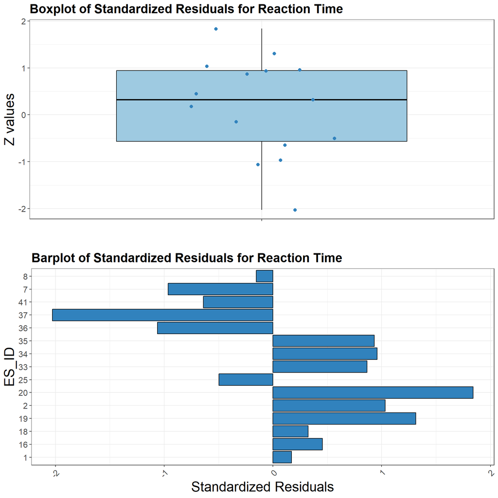

```r
calculate_residuals <- function(RT = FALSE, ACC = FALSE, outlier_threshold = 2) {
    # Ensure that either RT or ACC is TRUE, but not both
    if (RT == TRUE && ACC == TRUE) {
        stop("Only one of RT or ACC should be TRUE")
    } else if (RT == FALSE && ACC == FALSE) {
        stop("At least one of RT or ACC should be TRUE")
    }

    # Select the appropriate data based on RT or ACC
    data_selected <- if (RT) {
        plottitle <- "Reaction Time"
        calculate_meta(RT = TRUE )$model_multi
    } else if (ACC) {
        plottitle <- "Accuracy"
        calculate_meta(ACC = TRUE)$model_multi
    }

    # Standardized residuals
    res_mod_all_ml <- rstandard(data_selected)
    res_mod_all_plain <- residuals(data_selected)

    # Determine the appropriate dataset for the ID
    data_for_ID <- if (RT) data_RT else data_ACC

    # Set up the plotting area
    par(mfrow = c(1, 2))

    # Boxplot
    data_for_boxplot <- data.frame(z = res_mod_all_ml$z, ID = data_for_ID$ES_ID)
    data_for_barplot <- data.frame(ID = sort(data_for_ID$ES_ID), Residuals = res_mod_all_ml$z)
    data_for_barplot$ID <- factor(data_for_barplot$ID, levels = sort(data_for_barplot$ID))

  # Set up the color palette
  color_palette <- brewer.pal(3, "Blues")

  # Boxplot
  boxplot <- ggplot(data_for_boxplot, aes(x = "", y = z)) +
    geom_boxplot(fill = color_palette[2], color = "black", outlier.shape = NA) +
    geom_jitter(width = 0.2, size = 2, color = color_palette[3]) +
    labs(y = "Z values", x = "", title = paste("Boxplot of Standardized Residuals for", plottitle)) +
    theme_bw() +
    theme(
      plot.title = element_text(size = 18, face = "bold"),
      axis.title = element_text(size = 20),
      axis.text = element_text(size = 12)
    )

  barplot <- ggplot(data_for_barplot, aes(x = ID, y = Residuals)) +
    geom_bar(stat = "identity", position = position_dodge(), fill = color_palette[3], color = "black") +
    coord_flip() +
    labs(x = "ES_ID", y = "Standardized Residuals", title = paste("Barplot of Standardized Residuals for", plottitle)) +
    theme_bw() +
    theme(
      plot.title = element_text(size = 18, face = "bold"),
      axis.title = element_text(size = 20),
      axis.text.x = element_text(angle = 45, hjust = 1, size = 12),
      axis.text.y = element_text(size = 12)
    )

  # Display
  library(gridExtra)
  grid.arrange(boxplot, barplot, ncol = 1)

    # outlier handling:
    # outliers based on standardized residuals > multi_outlier
    outliers_indices <- which(abs(res_mod_all_ml$z) > outlier_threshold)
    # Extract the corresponding rows from the dataset
    outlier_studies <- data_for_ID[outliers_indices, ]

    # outlier studies
    print((outlier_studies))
    return(invisible(res_mod_all_ml))
}

calculate_residuals(RT = TRUE, outlier_threshold = 2)
```

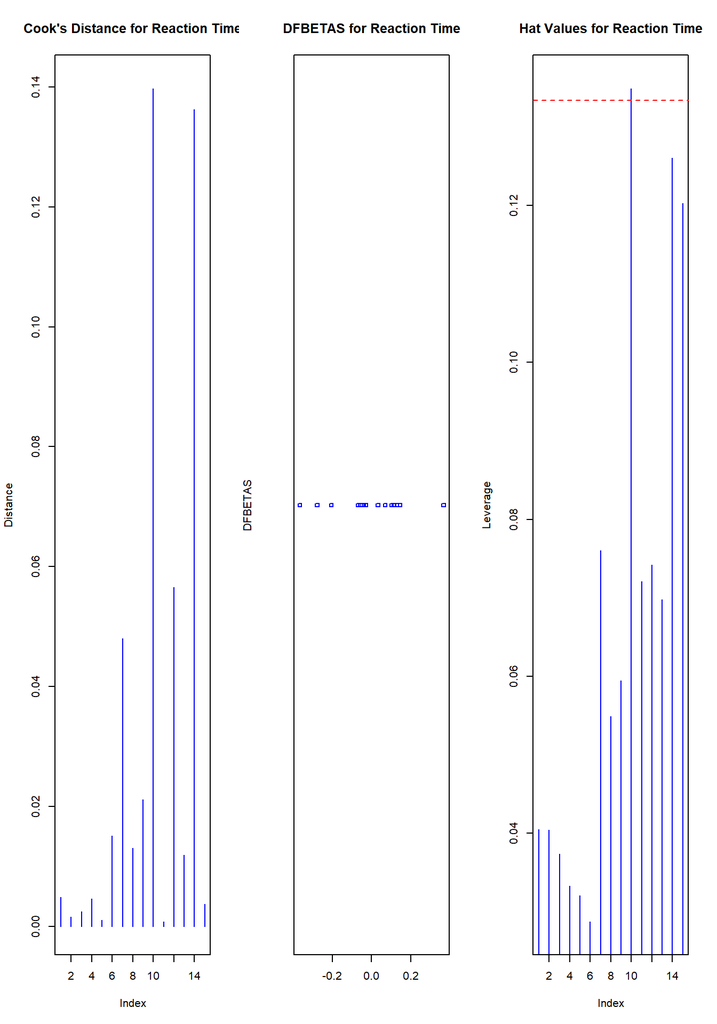

```r
library(ggplot2)
library(gridExtra) # For arranging ggplot2 plots
run_diagnostics <- function(data_type) {
    if (!data_type %in% c("RT", "ACC")) {
        stop("data_type must be either 'RT' or 'ACC'.")
    }

    # Determine the title prefix based on the data type
    title_prefix <- if (data_type == "RT") "Reaction Time" else "Accuracy"

    # Run the meta-analysis with multilevel modeling
    model <- calculate_meta(RT = data_type == "RT", ACC = data_type == "ACC")$model_multi

    # Set up the plotting area to display three plots side by side
    par(mfrow = c(1, 3))

    # Cook's Distance
    cooks <- cooks.distance(model)
    print(nrow(cooks))
    plot(cooks, type = "h", main = paste("Cook's Distance for", title_prefix), ylab = "Distance", col = "blue")
    abline(h = 4 / (length(cooks) - 2), col = "red", lty = 2)

    # DFBETAS
    dfbetas_values <- dfbetas(model)
    plot(dfbetas_values, main = paste("DFBETAS for", title_prefix), ylab = "DFBETAS", col = "blue")

    # Hat Values
    hatvals <- hatvalues(model, type = "diagonal")
    plot(hatvals, type = "h", main = paste("Hat Values for", title_prefix), ylab = "Leverage", col = "blue")
    abline(h = 2 * mean(hatvals), col = "red", lty = 2)

    # Reset the plotting layout
    par(mfrow = c(1, 1))
}
# Example call to the function for Reaction Time
run_diagnostics("RT")
```

```r
library(metafor)
library(ggplot2)
library(gridExtra)

# Function to calculate and plot diagnostic measures
diagnostic_analysis <- function(data_type, threshold = 2) {
    # Validate the data type
    if (!data_type %in% c("RT", "ACC")) {
        stop("data_type must be either 'RT' or 'ACC'.")
    }

    # Select the appropriate dataset and calculate the meta-analysis model
    if (data_type == "RT") {
        data <- data_RT
    } else {
        data <- data_ACC
    }
    model <- calculate_meta(RT = data_type == "RT", ACC = data_type == "ACC")$model_multi

    n <- nrow(data)

    # Calculating Cook's Distance
    cooks <- cooks.distance(model)
    print("Number of Cook's Distances:")
    class(cooks)
    outliers_cooks <- which(cooks > 4 / (n - 2))
    print("oputliers cooks")
    data[outliers_cooks, "ES_ID"]

    # Calculating Hat Values
    hatvals <- hatvalues(model)
    class(hatvals)
    outliers_hatvals <- which(hatvals > 2 * mean(hatvals))
    print("outliers hatvals")
    data[outliers_hatvals, "ES_ID"]

    # Calculating DFBETAS
    dfbetas_values <- dfbetas(model)
    outliers_dfbetas <- which(abs(dfbetas_values[, "intrcpt"]) > 2 / sqrt(n))
    print(" outliers dfbetas")
    data[outliers_dfbetas, "ES_ID"]

    outliers <- unique(c(outliers_cooks, outliers_hatvals, outliers_dfbetas))
    # outliers <- unique(c( outliers_hatvals, outliers_dfbetas))

    # Create a data frame with outlier information
    outlier_info <- data.frame(
        ES_ID = data[outliers, "ES_ID"],
        PlotLabel = data[outliers, "PlotLabel"],
        CognitiveFunction = data[outliers, "CognitiveFunction"],
        Criterion = c(
            # rep("Cook's Distance", length(outliers_cooks)),
            rep("Hat Values", length(outliers_hatvals)),
            rep("DFBETAS", length(outliers_dfbetas))
        )
    )

    # Exclude outliers and refit the model
    data_no_outliers <- data[-outliers, ]
    model_no_outliers <- rma.mv(
        yi = data_no_outliers[[ifelse(data_type == "RT", "ES_final_RT", "ES_final_ACC")]],
        V = data_no_outliers[[ifelse(data_type == "RT", "ES_var_RT", "ES_var_ACC")]],
        random = ~ 1 | ID / ES_ID,
        data = data_no_outliers,
        test = "t",
        method = "REML",
        slab = data_no_outliers$ES_ID
    )
    variance_analysis <- mlm.variance.distribution(model_no_outliers)
    # Plotting Cook's Distance
    plot_cooks <- ggplot(
        data.frame(Index = seq_along(cooks), Cooks = cooks),
        aes(x = Index, y = Cooks)
    ) +
        geom_bar(stat = "identity", fill = "skyblue") +
        geom_hline(yintercept = 4 / (n - 2), col = "red", linetype = "dashed") +
        labs(title = "Cook's Distance", x = "Study ID", y = "Distance") +
        scale_x_continuous(breaks = seq_along(cooks), labels = seq_along(cooks)) +
        scale_y_continuous(n.breaks = 2 * 5) +
         theme(
        axis.title = element_text(size = 14),
        axis.text = element_text(size = 12),
        plot.title = element_text(size = 16, face = "bold")
    )

    # Plotting Hat Values
    plot_hatvals <- ggplot(
        data.frame(Index = seq_along(hatvals), Hat = hatvals),
        aes(x = Index, y = Hat)
    ) +
        geom_bar(stat = "identity", fill = "lightgreen") +
        geom_hline(yintercept = 2 * mean(hatvals), col = "red", linetype = "dashed") +
        labs(title = "Hat Values", x = "Study ID", y = "Leverage") +
        scale_x_continuous(breaks = seq_along(hatvals), labels = seq_along(hatvals)) +
        scale_y_continuous(n.breaks = 2 * 5) +
         theme(
        axis.title = element_text(size = 14),
        axis.text = element_text(size = 12),
        plot.title = element_text(size = 16, face = "bold")
    )

    # Plotting DFBETAS for each coefficient
    plot_dfbetas <- list()
    for (i in seq_along(coef(model))) {
        plot_dfbetas[[i]] <- ggplot(
            data = data.frame(
                Index = seq_along(dfbetas_values[, i]),
                DFBETAS = dfbetas_values[, i]
            ),
            aes(x = Index, y = DFBETAS)
        ) +
            geom_bar(stat = "identity", fill = "orange") +
            geom_hline(
                yintercept = c(-threshold / sqrt(n), threshold / sqrt(n)),
                col = "red", linetype = "dashed"
            ) +
            labs(
                title = paste("DFBETAS for Coefficient", names(coef(model))[i]),
                x = "Study ID", y = "DFBETAS"
            ) + scale_x_continuous(breaks = seq_along(dfbetas_values[, i]), labels = seq_along(dfbetas_values[, i])) +
            scale_y_continuous(n.breaks = 2 * 5) +
             theme(
        axis.title = element_text(size = 14),
        axis.text = element_text(size = 12),
        plot.title = element_text(size = 16, face = "bold")
    )
    }

    # Arrange plots
    plots <- list(plot_cooks, plot_hatvals)
    plots <- c(plots, plot_dfbetas)
    arranged_plots <- grid.arrange(grobs = plots, ncol = 2)

    # Returning summary information with additional columns
    diagnostic_data <- data.frame(
        # Effectsize_ID = data[, "ES_ID"],
        Study = data[, "PlotLabel"],
        CognitiveFunction = data[, "CognitiveFunction"],
        Cooks_Distance = cooks,
        Leverage = hatvals,
        DFBETAS_intercept = dfbetas_values[, "intrcpt"]
    )

    return(list(
        plots = arranged_plots,
        summary_table = diagnostic_data,
        outlier_info = outlier_info,
        model_no_outliers = model_no_outliers,
        variance_analysis = variance_analysis
    ))
}


results <- diagnostic_analysis("RT")
```

```
## [1] "Number of Cook's Distances:"
## [1] "oputliers cooks"
## [1] "outliers hatvals"
## [1] " outliers dfbetas"
```

```r
# # Display the outlier information
print(results$outlier_info)
```

```
##   ES_ID               PlotLabel      CognitiveFunction  Criterion
## 1    34 Mallaroni et al. (2023) Cognitive  Flexibility Hat Values
```

```r
print(results$model_no_outliers)
```

```
##
## Multivariate Meta-Analysis Model (k = 14; method: REML)
##
## Variance Components:
##
##             estim    sqrt  nlvls  fixed    factor
## sigma^2.1  0.2632  0.5130      6     no        ID
## sigma^2.2  0.0119  0.1093     14     no  ID/ES_ID
##
## Test for Heterogeneity:
## Q(df = 13) = 31.5279, p-val = 0.0028
##
## Model Results:
##
## estimate      se    tval  df    pval   ci.lb   ci.ub
##   1.0949  0.2609  4.1963  13  0.0010  0.5312  1.6585  **
##
## ---
## Signif. codes:  0 '***' 0.001 '**' 0.01 '*' 0.05 '.' 0.1 ' ' 1
```

```r
print(results$summary_table)
```

```
##                               Study      CognitiveFunction Cooks_Distance
## 1             Cavanna et al. (2022)    Conflict monitoring   0.0048798741
## 2             Cavanna et al. (2022)              Attention   0.0015937097
## 7             Cavanna et al. (2022) Cognitive  Flexibility   0.0024243752
## 8             Barrett et al. (2017)         Working Memory   0.0046166474
## 36            Barrett et al. (2017)    Conflict monitoring   0.0010612941
## 37 Gouzoulis-Mayfrank et al. (2002)              Attention   0.0151383535
## 35            Quednow et al. (2011)    Conflict monitoring   0.0480223627
## 33          Mallaroni et al. (2023)              Attention   0.0130405445
## 34          Mallaroni et al. (2023) Cognitive  Flexibility   0.0211176751
## 41          Mallaroni et al. (2023) Cognitive  Flexibility   0.1397467055
## 16       Vollenweider et al. (1998)         Working Memory   0.0007929514
## 18            Barrett et al. (2017)         Working Memory   0.0565671905
## 19            Barrett et al. (2017)    Conflict monitoring   0.0118681978
## 20            Barrett et al. (2017)         Working Memory   0.1362529539
```

[output cut: 17 more lines]

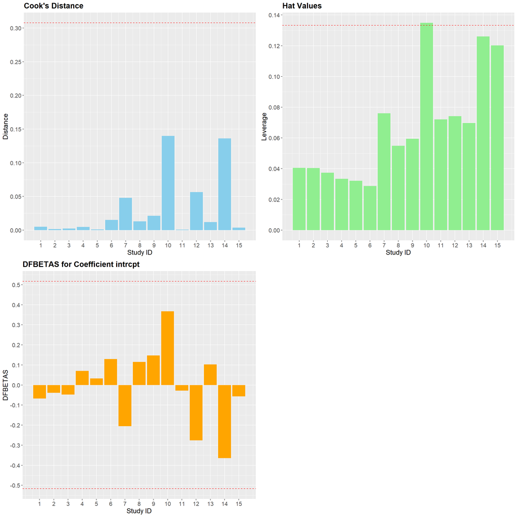

```r
print(results$plots)
```

# 3.4.1.2 Publication Bias RT

```r
publication_bias <- function(data_type) {
  # Determine which type of data to use
  if (data_type == "RT") {
    model_results <- calculate_meta(RT = TRUE)
    data <- data_RT
  } else if (data_type == "ACC") {
    model_results <- calculate_meta(ACC = TRUE)
    data <- data_ACC
  } else {
    stop("Invalid data type specified. Use 'RT' or 'ACC'.")
  }

  # Perform Kendall's tau rank correlation test
  kendalls_tau <- ranktest(x = data$ES_final, vi = data$ES_var)
  print(kendalls_tau)

  # Calculate fail-safe numbers
  fsn_rosenthal <- fsn(x = data$ES_final, vi = data$ES_var, type = "Rosenthal")
  print(fsn_rosenthal)

  fsn_orwin <- fsn(x = data$ES_final, vi = data$ES_var, type = "Orwin", target = 0.1)
  print(fsn_orwin)

  fsn_rosenberg <- fsn(x = data$ES_final, vi = data$ES_var, type = "Rosenberg")
  print(fsn_rosenberg)
}


publication_bias("RT")
```

```
##
## Rank Correlation Test for Funnel Plot Asymmetry
##
## Kendall's tau = 0.6190, p = 0.0008
##
##
## Fail-safe N Calculation Using the Rosenthal Approach
##
## Observed Significance Level: <.0001
## Target Significance Level:   0.05
##
## Fail-safe N: 515
##
##
## Fail-safe N Calculation Using the Orwin Approach
##
## Average Effect Size: 1.0852
## Target Effect Size:  0.1000
##
## Fail-safe N: 148
##
##
## Fail-safe N Calculation Using the Rosenberg Approach
##
## Average Effect Size:         1.0852
## Observed Significance Level: <.0001
## Target Significance Level:   0.05
##
## Fail-safe N: 304
```

```r
mod_egger <- function(data_type) {
  # Determine which type of data and model to use
  if (data_type == "RT") {
    model_results <- calculate_meta(RT = TRUE)
    data <- data_RT
    yi <- data$ES_final_RT
    V <- data$ES_var_RT
  } else if (data_type == "ACC") {
    model_results <- calculate_meta(ACC = TRUE)
    data <- data_ACC
    yi <- data$ES_final_ACC
    V <- data$ES_var_ACC
  } else {
    stop("Invalid data type specified. Use 'RT' or 'ACC'.")
  }

  # Perform the regression analysis using rma.mv
  mod_egger <- rma.mv(
    yi = yi,
    V = V,
    mods = ~ I(1 / sqrt(V)),  # precision as moderator
    random = ~ 1 | ID/ ES_ID,
    data = data
  )
  # Print the summary of the model
  summary(mod_egger)
}

# Example usage:
mod_egger("RT")
```

```
##
## Multivariate Meta-Analysis Model (k = 15; method: REML)
##
##   logLik  Deviance       AIC       BIC      AICc
##  -8.2681   16.5362   24.5362   26.7960   29.5362
##
## Variance Components:
##
##             estim    sqrt  nlvls  fixed    factor
## sigma^2.1  0.0009  0.0302      6     no        ID
## sigma^2.2  0.0000  0.0003     15     no  ID/ES_ID
##
## Test for Residual Heterogeneity:
## QE(df = 13) = 11.2724, p-val = 0.5880
##
## Test of Moderators (coefficient 2):
## QM(df = 1) = 21.8743, p-val < .0001
##
## Model Results:
##
##               estimate      se     zval    pval    ci.lb    ci.ub
## intrcpt         3.9058  0.6148   6.3526  <.0001   2.7008   5.1109  ***
## I(1/sqrt(V))   -1.2410  0.2653  -4.6770  <.0001  -1.7611  -0.7210  ***
##
## ---
## Signif. codes:  0 '***' 0.001 '**' 0.01 '*' 0.05 '.' 0.1 ' ' 1
```

```r
funnel_plot <- function(RT = FALSE, ACC = FALSE) {
    library(metafor)
    library(RColorBrewer)

    # Fetch the model results using calculate_meta
    if (RT) {
        model_results <- calculate_meta(RT = TRUE)
        egger_results <- mod_egger("RT")
        funnel_title <- "Funnel plot for the multilevel model of Reaction Time"
        plot_data <- data_RT
        plot_data$yi <- plot_data$ES_final_RT
        plot_data$sei <- sqrt(plot_data$ES_var_RT)
        xlab_text <- "Reaction Time (Hedges' g)"
        xlim_values <- c(-1, 3)
        ylim_values <- c(0.6, 0.3)
        color_points <- brewer.pal(length(unique(plot_data$PlotLabel)), "Dark2")
    } else if (ACC) {
        model_results <- calculate_meta(ACC = TRUE)
        egger_results <- mod_egger("ACC")
        funnel_title <- "Funnel plot for the multilevel model of Accuracy"
        plot_data <- data_ACC
        plot_data$yi <- plot_data$ES_final_ACC
        plot_data$sei <- sqrt(plot_data$ES_var_ACC)
        xlab_text <- "Accuracy (Hedges' g)"
        xlim_values <- c(-2.5, 2)
        ylim_values <- c(0.8, 0.2)
        color_points <- brewer.pal(length(unique(plot_data$PlotLabel)), "Paired")
    } else {
        stop("Either RT or ACC must be set to TRUE.")
    }

    color_mapping <- setNames(color_points[1:length(unique(plot_data$PlotLabel))], unique(plot_data$PlotLabel))

    # Create a mapping for shapes based on DoseLabel
    shape_mapping <- setNames(c(16, 17, 18, 19)[1:length(unique(plot_data$CognitiveFunction))], unique(plot_data$CognitiveFunction))

    # Create a mapping for sizes based on DoseLabel (example sizes, adjust as needed)
    size_mapping <- setNames(seq(1, length(unique(plot_data$DoseLabel)))[1:length(unique(plot_data$DoseLabel))], unique(plot_data$DoseLabel))


    model <- model_results$model_multi
    model_uni <- model_results$model_uni
    trim <- trimfill(model_uni)
    print(trim)

    # Create a data frame for the points with colors and shapes
    point_data <- data.frame(
        x = plot_data$yi,
        y = plot_data$sei,
        col = color_mapping[plot_data$PlotLabel],
        pch = shape_mapping[plot_data$CognitiveFunction],
        cex = size_mapping[rev(plot_data$DoseLabel)]
    )

    # Extract the filled studies
    filled_indices <- trim$fill
    filled_studies <- trim$yi[filled_indices]
    filled_sei <- sqrt(trim$vi[filled_indices])
    print(filled_studies)

    # Set up the graphical environment
    par(mfrow = c(1, 1), tck = -.03, mgp = c(6, 3, 0), mar = c(8, 10, 5, 6), bg = "white",
        cex.main = 1.5, # Font size for the main title
        cex.lab = 10,  # Font size for the axis titles
        cex.axis = 2  # Font size for the axis tick labels
    )

    cantour_shades <- brewer.pal(9,"Blues")[c(2, 4, 6)]

    # Save the plot as PNG
    file_path <- file.path(getwd(), "figures", ifelse(RT, "funnelplot_RT.png", "funnelplot_ACC.png"))
    png(filename = file_path, width = 2500, height = 3000, res = 300)

    # Create a contour-enhanced funnel plot
    funnel(model,
        refline2 = c(model_uni$beta),
        refline = c(0),
        lty = c(0, 0),
        level = c(90, 95, 99), # Adding multiple levels for contours
        shade = cantour_shades,
        label = "none", # Label all points with study labels
        slab = plot_data$ES_ID,
        xlab = xlab_text,
        back = "white",
        cex = 2,
        lwd = 3,
        xlim = xlim_values,
        ylim = ylim_values,
        digits = c(2, 2)
    )

    # Add the points using the points function with varying shapes
    points(point_data$x, point_data$y, col = point_data$col, pch = point_data$pch, cex = point_data$cex)

    # Add filled studies
    points(filled_studies, filled_sei, col = "red", pch = 4, cex = 2)

    # Add labels on top of each point
    text(point_data$x, point_data$y, labels = plot_data$ES_ID, pos = 3, offset = 1.5, cex = 1) # 'pos = 3' places the label above the point

    legend_data <- data.frame(ID = unique(plot_data$ID), PlotLabel = unique(plot_data$PlotLabel))
    print(legend_data)

    # Add legend for color, shape, and size

    # Add legend for study labels (colors)
    legend("topright", inset = c(0, 0),
        legend = legend_data$PlotLabel,
        fill = color_mapping[legend_data$PlotLabel],
        col = NA,
        pch = NA,
        #lty = NA,
        y.intersp = 0.6,
        x.intersp = 0.2,
        title = "Study"
    )

    # Add legend for cognitive functions (shapes)
    legend("topright", inset = c(0, 0.2),
        legend = names(shape_mapping),
        col = 1,
        pch = shape_mapping,
        pt.cex = 2,
        #lty = NA,
        y.intersp = 0.6,
        x.intersp = 0.8,
        title = "Cognitive Function"
    )
     # Add legend for confidence intervals and trim-and-fill
    legend("topright", ncol = 1,inset = c(0, 0.32),
        legend = c("90% CI", "95% CI", "99% CI", "Trim and Fill"),
        fill = c(cantour_shades, NA),
        col = c(rep(NA, length(cantour_shades)), "red"),
        pch = c(rep(NA, length(cantour_shades)), 4),
        lty = 0,
        y.intersp = 0.6,
        x.intersp = 0.5,
        text.width = max(strwidth(c("90% CI", "95% CI", "99% CI", "Trim and Fill"))) * 1,
     )
    # Add legend for dose labels (sizes)
    legend("topright", inset = c(0, 0.41),
        legend = names(size_mapping),
        col = 1,
        pch = 1,
        pt.cex = size_mapping,
        #lty = NA,
        y.intersp = 0.8,
        x.intersp = 2,
        title = "Doseage"
    )



    dev.off()
}



funnel_plot(ACC = TRUE)
```

```
##
## Estimated number of missing studies on the right side: 0 (SE = 2.9146)
##
## Random-Effects Model (k = 27; tau^2 estimator: REML)
##
## tau^2 (estimated amount of total heterogeneity): 0.1256 (SE = 0.1091)
## tau (square root of estimated tau^2 value):      0.3543
## I^2 (total heterogeneity / total variability):   32.09%
## H^2 (total variability / sampling variability):  1.47
##
## Test for Heterogeneity:
## Q(df = 26) = 39.7412, p-val = 0.0414
##
## Model Results:
##
## estimate      se     tval  df    pval    ci.lb   ci.ub
##  -0.0936  0.1235  -0.7576  26  0.4555  -0.3474  0.1603
##
## ---
## Signif. codes:  0 '***' 0.001 '**' 0.01 '*' 0.05 '.' 0.1 ' ' 1
##
## numeric(0)
```

```
##    ID                  PlotLabel
## 1   3      Cavanna et al. (2022)
## 2   6        Hasler et al (2004)
## 3  11    Marschall et al. (2022)
## 4   1      Barrett et al. (2017)
## 5   2       Carter et al. (2005)
## 6   7      Kometer et al. (2012)
## 7   8      Quednow et al. (2011)
## 8  10     Wittmann et al. (2006)
## 9  12    Mallaroni et al. (2023)
## 10  9 Vollenweider et al. (2007)
```

# 3.4.1.3 Model comparison Reaction Time

```r
calculate_meta(RT = TRUE)$model_comparison
```

```
##
##         df     AIC     BIC    AICc   logLik    LRT   pval      QE
## Full     3 31.3348 33.2520 33.7348 -12.6674               33.5458
## Reduced  2 34.2742 35.5523 35.3651 -15.1371 4.9394 0.0263 33.5458
```

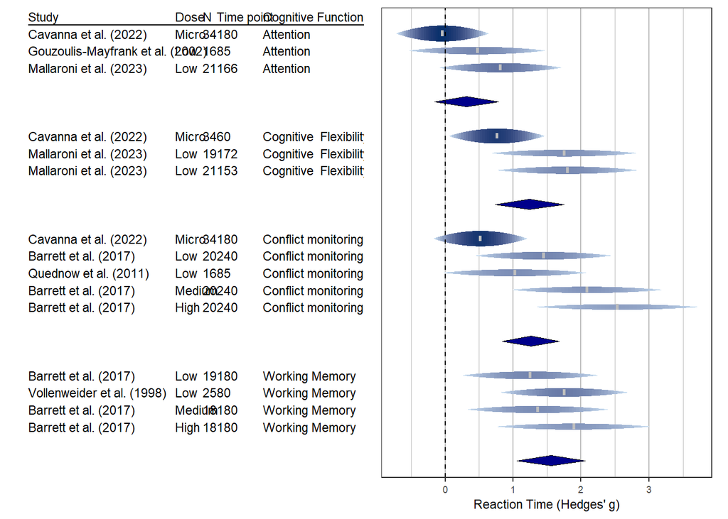

```r
forest_plot_metaviz <- function(RT = FALSE, ACC = FALSE) {
  library(metaviz)
  library(RColorBrewer)

  # Fetch the model results using calculate_meta
  if (RT) {
    model_results <- calculate_meta(RT = TRUE)
    plot_data <- data_RT
    plot_data$yi <- plot_data$ES_final_RT
    plot_data$sei <- sqrt(plot_data$ES_var_RT)
    xlab_text <- "Reaction Time (Hedges' g)"
  } else if (ACC) {
    model_results <- calculate_meta(ACC = TRUE)
    plot_data <- data_ACC
    plot_data$yi <- plot_data$ES_final_ACC
    plot_data$sei <- sqrt(plot_data$ES_var_ACC)
    xlab_text <- "Accuracy (Hedges' g)"
  } else {
    stop("Either RT or ACC must be set to TRUE.")
  }

  # Create a data frame for the table
  table_data <- data.frame(
    PlotLabel = plot_data$PlotLabel,
    DoseLabel = plot_data$DoseLabel,
    N_final = plot_data$N_final,
    Timepoint = plot_data$Timepoint,
    CognitiveFunction = plot_data$CognitiveFunction
  )

  # Create color palette for CognitiveFunction subgroups
  subgroup_colors <- brewer.pal(length(unique(plot_data$CognitiveFunction)), "Blues")
  names(subgroup_colors) <- unique(plot_data$CognitiveFunction)

  # Create the forest plot using viz_forest
  viz_forest(
    x = cbind(plot_data$yi, plot_data$sei),
    variant= "rain",
    #type = "sensitivity",
    study_labels = plot_data$PlotLabel,
    group = plot_data$CognitiveFunction,
    summary_label = names(subgroup_colors),
    col = subgroup_colors[1],
    summary_col = "darkblue",
    xlab = xlab_text,
    study_table = table_data,
    table_headers = c("Study", "Dose", "N", "Time point", "Cognitive Function"),
    table_layout = matrix(c(1, 2), nrow = 1)
    #row_spacing = 0.7

  )
}

forest_plot_metaviz(RT = TRUE)
```

```
## refline_lty will be deprecated, use refline_gp instead.
```

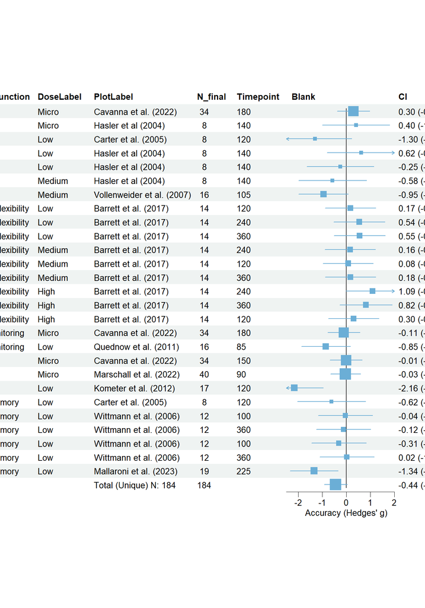

```r
library(metafor)
library(RColorBrewer)
library(forestploter)
library(grid)
library(dplyr)

forest_plot <- function(RT = FALSE, ACC = FALSE) {
  # Fetch the model results using calculate_meta
  if (RT) {
    model_results <- calculate_meta(RT = TRUE)
    plot_data <- data_RT
    plot_data$yi <- plot_data$ES_final_RT
    plot_data$sei <- sqrt(plot_data$ES_var_RT)
    forest_title <- "Forest plot for the multilevel model of Reaction Time"
    xlab_text <- "Reaction Time (Hedges' g)"
    xlim_values <- c(-1, 3)
  } else if (ACC) {
    model_results <- calculate_meta(ACC = TRUE)
    plot_data <- data_ACC
    plot_data$yi <- plot_data$ES_final_ACC
    plot_data$sei <- sqrt(plot_data$ES_var_ACC)
    forest_title <- "Forest plot for the multilevel model of Accuracy"
    xlab_text <- "Accuracy (Hedges' g)"
    xlim_values <- c(-2.5, 2)
  } else {
    stop("Either RT or ACC must be set to TRUE.")
  }

  # Create a data frame for the forest plot using original column names
  forest_data <- data.frame(
    CognitiveFunction = plot_data$CognitiveFunction,
    DoseLabel = plot_data$DoseLabel,
    PlotLabel = plot_data$PlotLabel,
    N_final = plot_data$N_final,
    Timepoint = plot_data$Timepoint,
    ES = as.numeric(plot_data$yi),
    LowerCI = as.numeric(plot_data$yi - 1.96 * plot_data$sei),
    UpperCI = as.numeric(plot_data$yi + 1.96 * plot_data$sei),
    CI = sprintf("%.2f (%.2f, %.2f)", plot_data$yi, plot_data$yi - 1.96 * plot_data$sei, plot_data$yi + 1.96 * plot_data$sei)
  )

  # Sort the dataframe by CognitiveFunction
  forest_data <- forest_data[order(forest_data$CognitiveFunction), ]

  # Add a blank column for the forest plot to display CI
  forest_data$Blank <- paste(rep(" ", 20), collapse = " ")

  # Calculate point sizes based on sample size
  plim <- c(0.5, 1.5)
  wi <- sqrt(forest_data$N_final)
  rng <- max(wi, na.rm=TRUE) - min(wi, na.rm=TRUE)
  if (rng <= .Machine$double.eps^0.5) {
    psize <- rep(1, nrow(forest_data))
  } else {
    psize <- (wi - min(wi, na.rm=TRUE)) / rng
    psize <- (psize * (plim[2] - plim[1])) + plim[1]
  }

  # Add psize to forest_data
  forest_data$psize <- psize

  # Calculate the overall N by counting each unique study only once
  overall_N <- forest_data %>%
    distinct(PlotLabel, .keep_all = TRUE) %>%
    summarise(total_n = sum(N_final)) %>%
    pull(total_n)

  # Add the overall Hedges' g row
  overall_row <- data.frame(
    CognitiveFunction = "Overall",
    DoseLabel = "",
    PlotLabel = paste("Total (Unique) N:", overall_N),
    N_final = overall_N,
    Timepoint = "",
    ES = as.numeric(model_results$model_multi$beta),
    LowerCI = as.numeric(model_results$model_multi$ci.lb),
    UpperCI = as.numeric(model_results$model_multi$ci.ub),
    CI = sprintf("%.2f (%.2f, %.2f)", model_results$model_multi$beta, model_results$model_multi$ci.lb, model_results$model_multi$ci.ub),
    Blank = paste(rep(" ", 20), collapse = " "),
    psize = max(psize)
  )

  forest_data <- rbind(forest_data, overall_row)

  # Set up the theme using Blues color palette
  blues_palette <- brewer.pal(9, "Blues")
  tm <- forest_theme(
    base_size = 10,
    refline_lty = "solid",
    ci_pch = 15,
    ci_col = blues_palette[5],
    footnote_gp = gpar(col = blues_palette[9]),
    vertline_lty = "dashed",
    vertline_col = blues_palette[3]
  )

  # Create the forest plot
  p <- forest(
    forest_data[, c("CognitiveFunction", "DoseLabel", "PlotLabel", "N_final", "Timepoint", "Blank", "CI")],
    est = forest_data$ES,
    lower = forest_data$LowerCI,
    upper = forest_data$UpperCI,
    sizes = forest_data$psize,  # Corrected from psizes to psize
    ci_column = 6,
    ref_line = 0,
    xlim = xlim_values,
    xlab = xlab_text,
    theme = tm
  )

  # Add title
  #p <- add_text(p, text = forest_title, part = "header", gp = gpar(fontface = "bold"))

  # Save the plot as PNG
  file_path <- file.path(getwd(), "figures", ifelse(RT, "forestplot_RT.png", "forestplot_ACC.png"))
  png(filename = file_path, width = 2800, height = 2200, res = 300)
  plot(p)
  dev.off()

  # Return the plot object
  return(p)
}

forest_plot(ACC = TRUE)
```

# 3.4.1.4 Subgroup Analyses RT

```r
# library(metafor)

moderation_analysis <- function(RT = FALSE, ACC = FALSE, moderation_var) {
    # Check that either RT or ACC is TRUE
    if (RT == TRUE && ACC == TRUE) {
        stop("Only one of RT or ACC should be TRUE")
    } else if (RT == FALSE && ACC == FALSE) {
        stop("At least one of RT or ACC should be TRUE")
    }

    # Select the appropriate data and columns based on RT or ACC
    if (RT) {
        data <- data_RT
        effect_size_col <- "ES_final_RT"
        variance_col <- "ES_var_RT"
    } else if (ACC) {
        data <- data_ACC
        effect_size_col <- "ES_final_ACC"
        variance_col <- "ES_var_ACC"
    }

    # Ensure the moderation variable exists in the data
    if (!moderation_var %in% names(data)) {
        stop(paste("The moderation variable", moderation_var, "is not in the dataset."))
    }

    # Convert moderation variable to a factor with specified reference category
    if (moderation_var == "EF_sensitivity") {
        data[[moderation_var]] <- factor(data[[moderation_var]], levels = c("3", "1", "2"))
    } else {
        data[[moderation_var]] <- as.factor(data[[moderation_var]])
    }
    if (moderation_var == "CognitiveFunction") {
        data[[moderation_var]] <- factor(data[[moderation_var]], levels = c("Attention", "Conflict monitoring", "Other EF", "Working Memory"))
    } else {
        data[[moderation_var]] <- as.factor(data[[moderation_var]])
    }

    # Running the mixed-effects model with moderation
    model <- rma.mv(
        yi = data[[effect_size_col]],
        V = data[[variance_col]],
        random = ~ 1 | ID / ES_ID,
        data = data,
        method = "REML",
        mods = as.formula(paste0("~", moderation_var))
    )

    # Return the summary of the model
    return(summary(model))
}
```

# 3.4.1.4.1 Timing as moderator RT

```r
ClassifyTiming <- function(data, start_peak, stop_peak) {
    # Ensure 'data' is a data frame
    if (!is.data.frame(data)) {
        stop("The 'data' argument must be a data frame.")
    }

    # Check if the "Timepoint (min)" column exists in the data frame
    if (!"Timepoint" %in% names(data)) {
        stop("The data frame does not contain a 'Timepoint (min)' column.")
    }

    # Initialize the 'timing' column to 0
    data$timing <- 0

    # Retrieve the "Timepoint (min)" column
    timepoint_col <- data[["Timepoint"]]

    # Classify as pre-peak (coded as 1)
    data$timing[timepoint_col < start_peak] <- 1

    # Classify as post-peak (coded as 1)
    data$timing[timepoint_col > stop_peak] <- 1

    # Classify as during peak (neither pre-peak nor post-peak, coded as 0)
    data$timing[timepoint_col >= start_peak & timepoint_col <= stop_peak] <- 0

    return(data)
}
```

```r
#
data_RT <- ClassifyTiming(data_RT, start_peak = 90, stop_peak = 180)
data_RT$timing <- as.factor(data_RT$timing)
nrow(data_RT)
```

```
## [1] 15
```

```r
length(unique(data_RT$ID))
```

```
## [1] 6
```

```r
moderation_analysis(RT = TRUE, moderation_var = "timing")
```

```
##
## Multivariate Meta-Analysis Model (k = 15; method: REML)
##
##   logLik  Deviance       AIC       BIC      AICc
## -11.2832   22.5665   30.5665   32.8263   35.5665
##
## Variance Components:
##
##             estim    sqrt  nlvls  fixed    factor
## sigma^2.1  0.3089  0.5558      6     no        ID
## sigma^2.2  0.0000  0.0000     15     no  ID/ES_ID
##
## Test for Residual Heterogeneity:
## QE(df = 13) = 31.0754, p-val = 0.0033
##
## Test of Moderators (coefficient 2):
## QM(df = 1) = 2.1926, p-val = 0.1387
##
## Model Results:
##
##          estimate      se    zval    pval    ci.lb   ci.ub
## intrcpt    0.8957  0.3144  2.8485  0.0044   0.2794  1.5120  **
## timing1    0.4177  0.2821  1.4808  0.1387  -0.1352  0.9706
##
## ---
## Signif. codes:  0 '***' 0.001 '**' 0.01 '*' 0.05 '.' 0.1 ' ' 1
```

```r
#data_ACC <- ClassifyTiming(data_ACC, start_peak = 90, stop_peak = 180)
```

# 3.4.1.4.2 Dosage as moderator RT

```r
moderation_analysis(RT = TRUE, moderation_var = "dosage_cat_all")
```

```
##
## Multivariate Meta-Analysis Model (k = 15; method: REML)
##
##   logLik  Deviance       AIC       BIC      AICc
##  -7.5263   15.0526   27.0526   29.4400   48.0526
##
## Variance Components:
##
##             estim    sqrt  nlvls  fixed    factor
## sigma^2.1  0.0000  0.0000      6     no        ID
## sigma^2.2  0.0145  0.1205     15     no  ID/ES_ID
##
## Test for Residual Heterogeneity:
## QE(df = 11) = 11.0247, p-val = 0.4412
##
## Test of Moderators (coefficients 2:4):
## QM(df = 3) = 20.7840, p-val = 0.0001
##
## Model Results:
##
##                  estimate      se    zval    pval    ci.lb   ci.ub
## intrcpt            0.4025  0.2131  1.8888  0.0589  -0.0152  0.8201    .
## dosage_cat_all1    0.8743  0.2803  3.1190  0.0018   0.3249  1.4237   **
## dosage_cat_all2    1.2997  0.4447  2.9227  0.0035   0.4281  2.1713   **
## dosage_cat_all3    1.7907  0.4717  3.7958  0.0001   0.8661  2.7153  ***
##
## ---
## Signif. codes:  0 '***' 0.001 '**' 0.01 '*' 0.05 '.' 0.1 ' ' 1
```

```r
moderation_analysis(RT = TRUE, moderation_var = "dosage_cat_micro")
```

```
##
## Multivariate Meta-Analysis Model (k = 15; method: REML)
##
##   logLik  Deviance       AIC       BIC      AICc
## -10.3184   20.6367   28.6367   30.8965   33.6367
##
## Variance Components:
##
##             estim    sqrt  nlvls  fixed    factor
## sigma^2.1  0.0455  0.2133      6     no        ID
## sigma^2.2  0.0264  0.1626     15     no  ID/ES_ID
##
## Test for Residual Heterogeneity:
## QE(df = 13) = 15.6622, p-val = 0.2679
##
## Test of Moderators (coefficient 2):
## QM(df = 1) = 7.7435, p-val = 0.0054
##
## Model Results:
##
##                    estimate      se    zval    pval    ci.lb   ci.ub
## intrcpt              0.4031  0.3080  1.3089  0.1906  -0.2005  1.0068
## dosage_cat_micro1    1.0121  0.3637  2.7827  0.0054   0.2992  1.7250  **
##
## ---
## Signif. codes:  0 '***' 0.001 '**' 0.01 '*' 0.05 '.' 0.1 ' ' 1
```

```r
moderation_analysis(RT = TRUE, moderation_var = "dosage_cat_microlow_vs_midhigh")
```

```
##
## Multivariate Meta-Analysis Model (k = 15; method: REML)
##
##   logLik  Deviance       AIC       BIC      AICc
## -10.6952   21.3903   29.3903   31.6501   34.3903
##
## Variance Components:
##
##             estim    sqrt  nlvls  fixed    factor
## sigma^2.1  0.1867  0.4321      6     no        ID
## sigma^2.2  0.0109  0.1046     15     no  ID/ES_ID
##
## Test for Residual Heterogeneity:
## QE(df = 13) = 22.4312, p-val = 0.0490
##
## Test of Moderators (coefficient 2):
## QM(df = 1) = 3.0163, p-val = 0.0824
##
## Model Results:
##
##                                  estimate      se    zval    pval    ci.lb
## intrcpt                            1.0337  0.2370  4.3610  <.0001   0.5691
## dosage_cat_microlow_vs_midhigh2    0.7113  0.4095  1.7367  0.0824  -0.0914
##                                   ci.ub
## intrcpt                          1.4983  ***
## dosage_cat_microlow_vs_midhigh2  1.5139    .
##
## ---
## Signif. codes:  0 '***' 0.001 '**' 0.01 '*' 0.05 '.' 0.1 ' ' 1
```

# 3.4.1.4.3 Cognitive function as moderator RT

```r
moderation_analysis(RT = TRUE, moderation_var = "CognitiveFunction")
```

```
##
## Multivariate Meta-Analysis Model (k = 12; method: REML)
##
##   logLik  Deviance       AIC       BIC      AICc
##  -7.4053   14.8106   24.8106   25.7967   44.8106
##
## Variance Components:
##
##             estim    sqrt  nlvls  fixed    factor
## sigma^2.1  0.2054  0.4532      6     no        ID
## sigma^2.2  0.0000  0.0000     12     no  ID/ES_ID
##
## Test for Residual Heterogeneity:
## QE(df = 9) = 14.9825, p-val = 0.0914
##
## Test of Moderators (coefficients 2:3):
## QM(df = 2) = 4.1541, p-val = 0.1253
##
## Model Results:
##
##                                       estimate      se    zval    pval    ci.lb
## intrcpt                                 0.5550  0.3369  1.6475  0.0995  -0.1053
## CognitiveFunctionConflict monitoring    0.7748  0.3830  2.0227  0.0431   0.0240
## CognitiveFunctionWorking Memory         0.6883  0.4707  1.4621  0.1437  -0.2344
##                                        ci.ub
## intrcpt                               1.2154  .
## CognitiveFunctionConflict monitoring  1.5255  *
## CognitiveFunctionWorking Memory       1.6109
##
## ---
## Signif. codes:  0 '***' 0.001 '**' 0.01 '*' 0.05 '.' 0.1 ' ' 1
```

```r
table(data_RT$CognitiveFunction)
```

```
##
##              Attention Cognitive  Flexibility    Conflict monitoring
##                      3                      3                      5
##         Working Memory
##                      4
```

# 3.4.1.4.4 EF sensitivity as moderator RT

```r
moderation_analysis(RT = TRUE, moderation_var = "EF_sensitivity")
```

```
##
## Multivariate Meta-Analysis Model (k = 15; method: REML)
##
##   logLik  Deviance       AIC       BIC      AICc
##  -8.2974   16.5947   26.5947   29.0193   36.5947
##
## Variance Components:
##
##             estim    sqrt  nlvls  fixed    factor
## sigma^2.1  0.1032  0.3212      6     no        ID
## sigma^2.2  0.0000  0.0000     15     no  ID/ES_ID
##
## Test for Residual Heterogeneity:
## QE(df = 12) = 14.7397, p-val = 0.2560
##
## Test of Moderators (coefficients 2:3):
## QM(df = 2) = 9.1582, p-val = 0.0103
##
## Model Results:
##
##                  estimate      se     zval    pval    ci.lb    ci.ub
## intrcpt            1.6923  0.2728   6.2041  <.0001   1.1577   2.2269  ***
## EF_sensitivity1   -0.9582  0.3194  -3.0003  0.0027  -1.5841  -0.3322   **
## EF_sensitivity2   -0.7182  0.3651  -1.9669  0.0492  -1.4339  -0.0025    *
##
## ---
## Signif. codes:  0 '***' 0.001 '**' 0.01 '*' 0.05 '.' 0.1 ' ' 1
```

```r
moderation_analysis(RT = TRUE, moderation_var = "ID")
```

```
##
## Multivariate Meta-Analysis Model (k = 15; method: REML)
##
##   logLik  Deviance       AIC       BIC      AICc
##  -6.4284   12.8567   28.8567   30.4345  172.8567
##
## Variance Components:
##
##             estim    sqrt  nlvls  fixed    factor
## sigma^2.1  0.0010  0.0316      6     no        ID
## sigma^2.2  0.0242  0.1556     15     no  ID/ES_ID
##
## Test for Residual Heterogeneity:
## QE(df = 9) = 9.4848, p-val = 0.3938
##
## Test of Moderators (coefficients 2:6):
## QM(df = 5) = 20.8008, p-val = 0.0009
##
## Model Results:
##
##          estimate      se     zval    pval    ci.lb    ci.ub
## intrcpt    1.7090  0.2310   7.3987  <.0001   1.2563   2.1618  ***
## ID12      -0.3165  0.3818  -0.8289  0.4072  -1.0647   0.4318
## ID13       0.0410  0.5475   0.0748  0.9404  -1.0322   1.1141
## ID3       -1.3060  0.3209  -4.0697  <.0001  -1.9350  -0.6770  ***
## ID5       -1.2397  0.5792  -2.1404  0.0323  -2.3748  -0.1045    *
## ID8       -0.6838  0.6012  -1.1374  0.2554  -1.8620   0.4945
##
## ---
## Signif. codes:  0 '***' 0.001 '**' 0.01 '*' 0.05 '.' 0.1 ' ' 1
```

```r
# table(data_RT$EF_sensitivity)
# head(data_RT)
```

# 3.4.1.4.5 Metaforest Analysis RT

```r
# code adapted from (Van Lissa, 2017)

# Set a seed for reproducibility
set.seed(242)
metaforest_formula <- ES_final_RT~CognitiveFunction + DoseLabel + EF_sensitivity + timing

run_metaforest_analysis <- function(data_type) {
    library(metaforest)
    library(dplyr)

    metaforest_formula <- ES_final_RT~CognitiveFunction + DoseLabel + EF_sensitivity + timing

    # Load and prepare data based on the specified data type
    if (data_type == "RT") {
        data_metaforest <- data_RT
        data_metaforest$timing <- as.factor(data_RT$timing)
        outcome_var <- "ES_final_RT"
        vi_variable <- "ES_var_RT"
        metaforest_formula <- ES_final_RT~CognitiveFunction + DoseLabel + EF_sensitivity + timing
    } else if (data_type == "ACC") {
        data_metaforest <- data_ACC
        data_metaforest$timing <- as.factor(data_ACC$timing)
        outcome_var <- "ES_final_ACC"
        vi_variable <- "ES_var_ACC"
        metaforest_formula <- ES_final_ACC~CognitiveFunction + DoseLabel + EF_sensitivity + timing
    } else {
        stop("Invalid data type specified. Use 'RT' or 'ACC'.")
    }
    # Debugging step: Check the structure of the dataset
    print("Data Structure:")
    print(str(data_metaforest))

    # Debugging step: Check the column names
    print("Column Names:")
    print(colnames(data_metaforest))

    # Debugging step: Check the first few rows of the dataset
    print("First Few Rows:")
    print(head(data_metaforest))

    # Convert factor variables explicitly if not already
    data_metaforest$CognitiveFunction <- as.factor(data_metaforest$CognitiveFunction)
    data_metaforest$DoseLabel <- as.factor(data_metaforest$DoseLabel)
    data_metaforest$EF_sensitivity <- as.factor(data_metaforest$EF_sensitivity)
    data_metaforest$dosage_cat_all <- as.factor(data_metaforest$dosage_cat_all)
    data_metaforest$ID <- as.factor(data_metaforest$ID)
    data_metaforest$timing <- as.factor(data_metaforest$timing)
    data_metaforest$ES_ID <- as.factor(data_metaforest$ES_ID)

    #check for convergence
    check_conv <- MetaForest(
        formula = metaforest_formula,
        data = data_metaforest,
        study = "ID", # grouping variable, because we have multiple effect sizes per study
        vi = vi_variable,
        whichweights = "random",
        method = "REML",
        num.trees = 20000
    )
    plot(check_conv,col = brewer.pal(9, "Blues")[5],
             cex.lab = 3,     # Increase the size of axis labels
         cex.axis = 3)  # Increase the size of axis tick labels)

    # rerun with reduced number of treesFfunnel
    metaforest_reduced <- MetaForest(
        formula = metaforest_formula,
        data = data_metaforest,
        study = "ID", # grouping variable, because we have multiple effect sizes per study
        vi = vi_variable,
        whichweights = "random",
        method = "REML",
        num.trees = 5000
    )

    # Run recursive preselection to refine the selection of moderators
    preselected <- preselect(metaforest_reduced, replications = 300, algorithm = "recursive")
    plot_variable_importance <- plot(preselected,col = brewer.pal(9, "Blues")[5],
             cex.lab = 3,     # Increase the size of axis labels
         cex.axis = 3) # Plot the results of the preselection

    # Retain only moderators with positive variable importance in more than 50% of replications
    retain_mods <- preselect_vars(preselected, cutoff = 0.5)

    # Print out the moderators that are retained
     print(retain_mods)

    results <- list(
        model = metaforest_reduced,
        preselected = preselected,
        plot_variable_importance = plot_variable_importance,
        retained_mods = retain_mods,
        check_conv = check_conv
    )

    return(results)
}
```

```r
#,cache = TRUE
retain_mods <- run_metaforest_analysis("RT")
```

```
## [1] "Data Structure:"
## 'data.frame':    15 obs. of  14 variables:
##  $ ID                            : Factor w/ 6 levels "1","12","13",..: 4 4 4 1 1 5 6 2 2 2 ...
##  $ ES_ID                         : Factor w/ 15 levels "1","16","18",..: 2 3 4 1 5 6 7 10 8 9 ...
##  $ CognitiveFunction             : Factor w/ 4 levels "Attention","Cognitive  Flexibility",..: 3 1 2 4 3 1 3 1 2 2 ...
##  $ N_final                       : num  34 34 34 19 20 16 16 21 19 21 ...
##  $ ES_final_RT                   : num  0.5149 -0.0411 0.7581 1.25 1.444 ...
##  $ ES_var_RT                     : num  0.122 0.118 0.126 0.252 0.252 ...
##  $ Timepoint                     : num  180 180 60 180 240 85 85 166 172 153 ...
##  $ PlotLabel                     : chr  "Cavanna et al. (2022)" "Cavanna et al. (2022)" "Cavanna et al. (2022)" "Barrett et al. (2017)" ...
##  $ DoseLabel                     : Factor w/ 4 levels "High","Low","Medium",..: 4 4 4 2 2 2 2 2 2 2 ...
##  $ EF_sensitivity                : Factor w/ 3 levels "1","2","3": 1 1 2 1 3 1 2 2 3 3 ...
##  $ dosage_cat_all                : Factor w/ 4 levels "0","1","2","3": 1 1 1 2 2 2 2 2 2 2 ...
##  $ dosage_cat_micro              : num  0 0 0 1 1 1 1 1 1 1 ...
##  $ dosage_cat_microlow_vs_midhigh: num  1 1 1 1 1 1 1 1 1 1 ...
```

[output cut: 33 more lines]

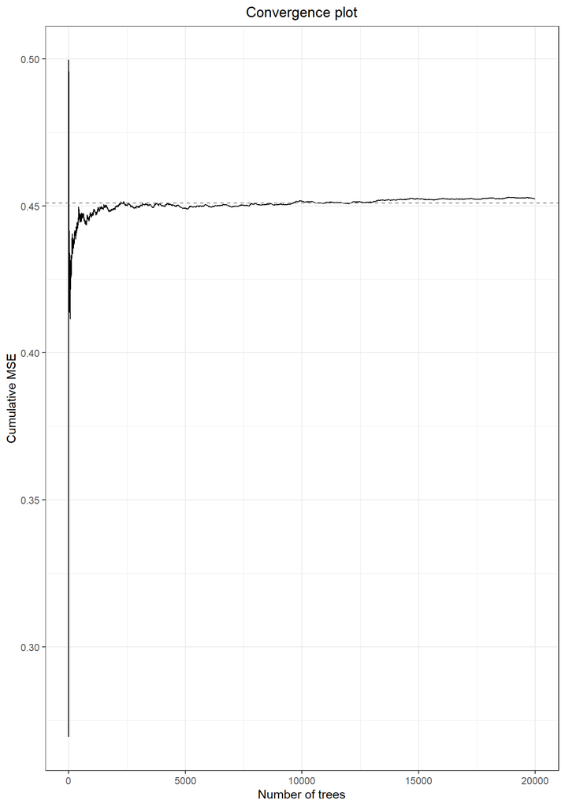

```r
conv <- retain_mods$check_conv
plot(conv)



save_plot <- function(conv) {
    file_path <- file.path(getwd(), "figures/supplementary", "Metaforest_RT_Conv.png")
    png(filename = file_path, width = 3500, height = 2200, res = 300)

    # Generate and save the plot
    plot(conv)

    dev.off()
}
save_plot(plot(conv))
```

```r
metaforest_formula <- ES_final_RT~CognitiveFunction + DoseLabel + EF_sensitivity + timing


# change nr of trees based on convergence!
retain_mods <- run_metaforest_analysis("RT")
```

```
## [1] "Data Structure:"
## 'data.frame':    15 obs. of  14 variables:
##  $ ID                            : Factor w/ 6 levels "1","12","13",..: 4 4 4 1 1 5 6 2 2 2 ...
##  $ ES_ID                         : Factor w/ 15 levels "1","16","18",..: 2 3 4 1 5 6 7 10 8 9 ...
##  $ CognitiveFunction             : Factor w/ 4 levels "Attention","Cognitive  Flexibility",..: 3 1 2 4 3 1 3 1 2 2 ...
##  $ N_final                       : num  34 34 34 19 20 16 16 21 19 21 ...
##  $ ES_final_RT                   : num  0.5149 -0.0411 0.7581 1.25 1.444 ...
##  $ ES_var_RT                     : num  0.122 0.118 0.126 0.252 0.252 ...
##  $ Timepoint                     : num  180 180 60 180 240 85 85 166 172 153 ...
##  $ PlotLabel                     : chr  "Cavanna et al. (2022)" "Cavanna et al. (2022)" "Cavanna et al. (2022)" "Barrett et al. (2017)" ...
##  $ DoseLabel                     : Factor w/ 4 levels "High","Low","Medium",..: 4 4 4 2 2 2 2 2 2 2 ...
##  $ EF_sensitivity                : Factor w/ 3 levels "1","2","3": 1 1 2 1 3 1 2 2 3 3 ...
##  $ dosage_cat_all                : Factor w/ 4 levels "0","1","2","3": 1 1 1 2 2 2 2 2 2 2 ...
##  $ dosage_cat_micro              : num  0 0 0 1 1 1 1 1 1 1 ...
##  $ dosage_cat_microlow_vs_midhigh: num  1 1 1 1 1 1 1 1 1 1 ...
```

[output cut: 33 more lines]

```r
print(retain_mods$preselected)
```

```
## Mean variable importance across bootstrap replications:
## named numeric(0)
##
## SD of variable importance across bootstrap replications:
## CognitiveFunction         DoseLabel    EF_sensitivity            timing
##                NA                NA                NA                NA
##
##
## R2 median:  0.2448235
## R2 sd: 0.5348906
```

```r
plot(retain_mods$preselected)
print(retain_mods$retained_mods)
```

```
## [1] "CognitiveFunction" "EF_sensitivity"
```

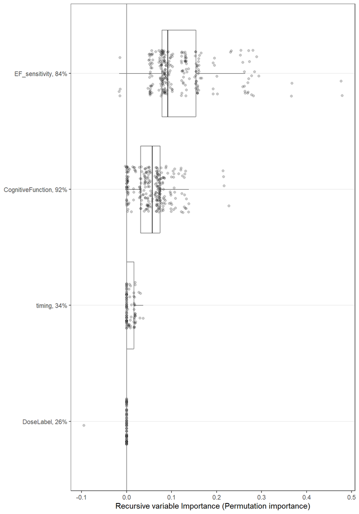

```r
save_plot <- function(preselected) {
    file_path <- file.path(getwd(), "figures/supplementary", "Metaforest_RT_Preselected.png")
    png(filename = file_path, width = 3500, height = 2200, res = 300)

    # Generate and save the plot
    plot(preselected)

    dev.off()
}
save_plot(plot(retain_mods$preselected))
```

```r
# code adapted from (Van Lissa, 2017)
library(caret)
library(metaforest)

fine_tune_metaforest <- function(data_type, predictors) {
    library(metaforest)
    library(dplyr)

    # Load and prepare data based on the specified data type
    if (data_type == "RT") {
        data <- data_RT
        outcome_var <- "ES_final_RT"
        vi_variable <- "ES_var_RT"
    } else if (data_type == "ACC") {
        data <- data_ACC
        outcome_var <- "ES_final_ACC"
        vi_variable <- "ES_var_ACC"
    } else {
        stop("Invalid data type specified. Use 'RT' or 'ACC'.")
    }

    set.seed(78)

    # Prepare the training control using grouped cross-validation
    grouped_cv <- trainControl(
        method = "cv",
        index = groupKFold(data$ID, k = length(unique(data$ID)))
    )

    # Set up a tuning grid for MetaForest
    tuning_grid <- expand.grid(
        whichweights = c("random", "fixed", "unif"),
        mtry = 1:2,
        min.node.size = 1:5
    )

    # Define the predictors and outcome

    # Ensure the dataset has only the necessary columns
    X <- data[, c("ID", vi_variable, predictors)]
    data$ID <- as.factor(data$ID)
    data$EF_sensitivity <- as.factor(data$EF_sensitivity)

    # Train the model
    mf_cv <- train(
        x = X,
        y = data[[outcome_var]],
        vi = vi_variable,
        study = "ID", # Clustering variable
        method = ModelInfo_mf(),
        trControl = grouped_cv,
        tuneGrid = tuning_grid,
        num.trees = 15000
    )

    final <- mf_cv$finalModel
    r2_oob <- final$forest$r.squared
    r2_cv <- mf_cv$results$Rsquared[which.min(mf_cv$results$RMSE)]
    return(list(
        model = mf_cv,
        r2_cv = r2_cv,
        final = final,
        r2_oob = r2_oob
    ))
}
```

```r
#, cache = TRUE}
predictors <- c("EF_sensitivity", "CognitiveFunction") # adjust based on previous analysis

mf_cv <- fine_tune_metaforest("RT", predictors)
# Check the results
print(mf_cv$r2_oob)
```

```
## [1] 0.6266048
```

```r
print(mf_cv$r2_cv)
```

```
## [1] 0.3950094
```

```r
final <- mf_cv$final

print(final)
```

[output not shown]

```r
# variable importance plot
varIm_RT <- VarImpPlot(final)
```

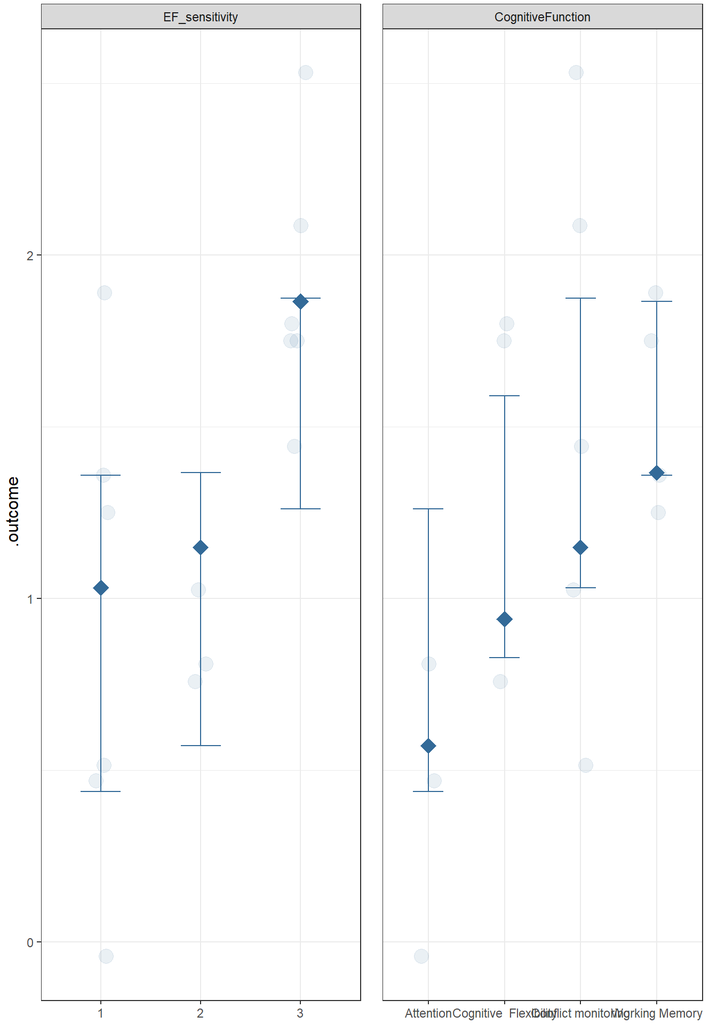

```r
# partial dependence plot
PartialDependence(final, rawdata = TRUE, pi = .95)
```

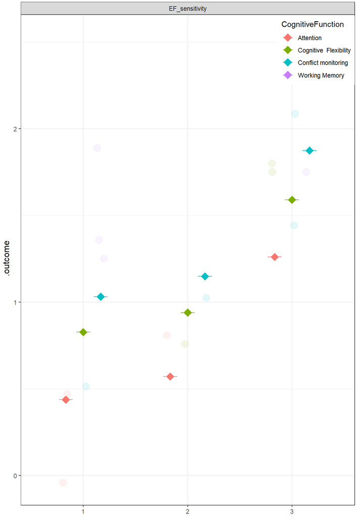

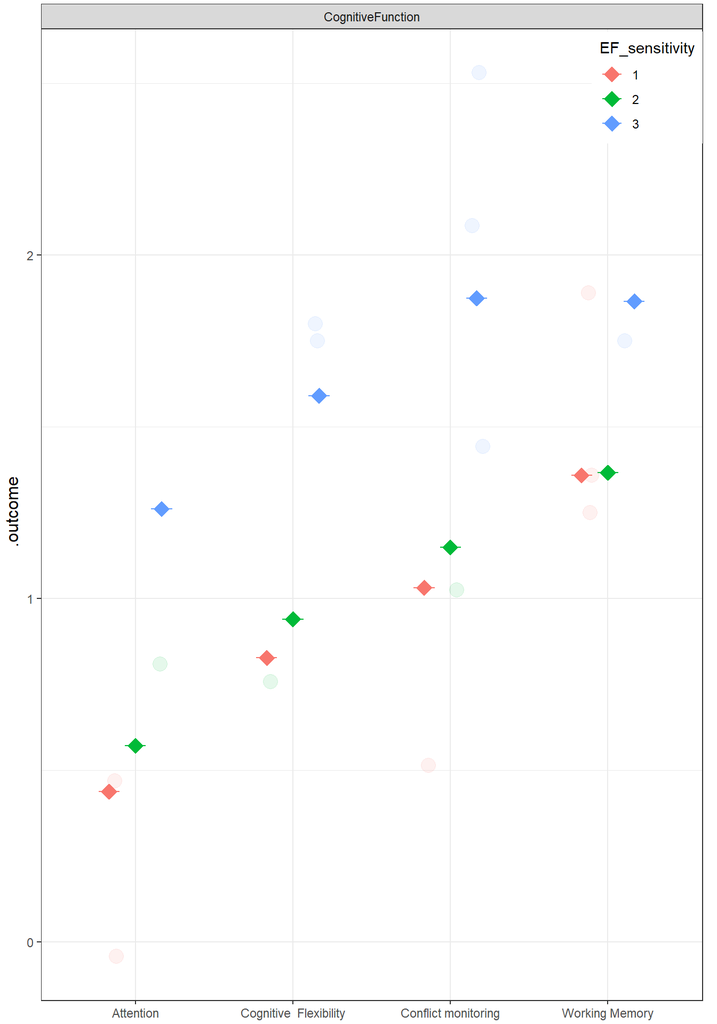

```r
# moderated partial dependence plot
PartialDependence(final, moderator = "CognitiveFunction", rawdata = TRUE, pi = .95)
PartialDependence(final, moderator = "EF_sensitivity", rawdata = TRUE, pi = .95)
```

# P & Z curve analysis RT

P-Curve-Analysis: The red dots represent the expected proportions of p-values in each bin under the null hypothesis. The null hypothesis assumes that there is no true effect and that the distribution of p-values should be uniform across all bins. In this case, the expected proportion for each bin is set to 0.2 (i.e., 20% of p-values are expected to fall into each bin if there is no true effect). The red dots are plotted at the positions corresponding to the expected proportions for each bin. They provide a visual reference to compare the observed proportions (represented by the blue bars) against the expected proportions under the null hypothesis. If the observed proportions deviate significantly from the expected proportions, it suggests that the distribution of p-values is not uniform and that there may be evidence of a true effect or potential publication bias. The chi-square test is used to assess the statistical significance of the difference between the observed and expected proportions.

Z-Curve-Analysis: Histogram of Z-scores: The bars represent the distribution of observed z-scores from the studies. The height of each bar indicates the density of studies with corresponding z-scores. Blue Density Curve: The solid blue curve represents the estimated density of true z-scores. It suggests what the distribution of z-scores would look like if there were no selection bias. The dashed blue curve might represent the confidence intervals or variability in the estimation.

Red Vertical Line: The red vertical line typically represents the threshold for statistical significance (e.g., a z-score of 1.96 corresponding to p < 0.05). Studies to the right of this line are considered statistically significant. Observed Discovery Rate (ODR): The proportion of studies with z-scores above the significance threshold. This rate is often higher than the true discovery rate due to publication bias. Expected Discovery Rate (EDR): This is inferred from the Z-curve and represents the mean power of all conducted studies, both significant and non-significant. It gives an estimate of the proportion of studies expected to produce statistically significant results if all studies were published.

```r
library(ggplot2)
library(zcurve)
library(gridExtra)
library(cowplot)
p_z_curve_analysis <- function(data_type) {
  if (data_type == "RT") {
    data <- data_RT
    effect_size_col <- "ES_final_RT"
    ES_var <- "ES_var_RT"
    title <- "Reaction Time"
  } else if (data_type == "ACC") {
    data <- data_ACC
    effect_size_col <- "ES_final_ACC"
    ES_var <- "ES_var_ACC"
    title <- "Accuracy"
  } else {
    stop("Invalid data_type. Please specify either 'RT' or 'ACC'.")
  }

  data$p_value <- 2 * pnorm(-abs(data[[effect_size_col]] / sqrt(data[[ES_var]])))

  # Extract p-values
  p_values <- data$p_value

  # Subset significant p-values (p < 0.05)
  significant_p <- p_values[p_values < 0.05]

  # Calculate the proportion of p-values in each bin
  bin_counts <- c(
    sum(significant_p <= 0.01),
    sum(significant_p > 0.01 & significant_p <= 0.02),
    sum(significant_p > 0.02 & significant_p <= 0.03),
    sum(significant_p > 0.03 & significant_p <= 0.04),
    sum(significant_p > 0.04 & significant_p <= 0.05)
  )

  # Calculate the expected proportions under the null hypothesis
  expected_proportions <- c(0.2, 0.2, 0.2, 0.2, 0.2)

  # Perform chi-square test
  chi_square_result <- suppressWarnings(chisq.test(bin_counts, p = expected_proportions))

  # Create a data frame with the results
  result_df <- data.frame(
    Bin = c("0.00-0.01", "0.01-0.02", "0.02-0.03", "0.03-0.04", "0.04-0.05"),
    Observed = bin_counts,
    Expected = expected_proportions * sum(bin_counts),
    Proportion = bin_counts / sum(bin_counts)
  )

  # Create p-curve plot
  p_plot <- ggplot(result_df, aes(x = Bin)) +
    geom_bar(aes(y = Proportion), stat = "identity", fill = "steelblue", alpha = 0.7) +
    geom_point(aes(y = Expected / sum(bin_counts)), color = "red", size = 3) +
    labs(x = "P-value Bin", y = "Proportion",
         title = paste("P-Curve Analysis -", title),
         subtitle = "Observed vs. Expected Proportions") +
    theme_minimal() +
    theme(plot.title = element_text(hjust = 0.5, size = 16, face = "bold"),
          plot.subtitle = element_text(hjust = 0.5, size = 12),
          axis.text = element_text(size = 10),
          axis.title = element_text(size = 12))

    # Try to fit the z-curve model
  fit <- NULL
  z_plot <- NULL

  tryCatch({
    fit <- zcurve(p = p_values)
    z_plot <- plot(fit, CI = TRUE, annotation = FALSE,
                   main = paste("Z-Curve Analysis -", title), plot_type = "ggplot")
  }, error = function(e) {
    message("Not enough significant p-values for z-curve analysis. Displaying only p-curve plot.")
    z_plot <- ggplot() +
      annotate("text", x = 0.5, y = 0.5,
               label = "Insufficient data for Z-curve analysis\n(less than 10 significant p-values)") +
      theme_void() +
      theme(plot.title = element_text(hjust = 0.5, size = 16, face = "bold"))
  })

  # Always create a combined plot, even if z_plot is just a placeholder
  combined_plot <- arrangeGrob(p_plot, z_plot, ncol = 2)

  # Return the results, including the combined plot
  list(
    p_curve_data = result_df,
    chi_square_test = chi_square_result,
    z_curve_fit = fit,
    p_plot = p_plot,
    z_plot = z_plot,
    combined_plot = combined_plot
  )
}



save_plot <- function(results, data_type) {
  file_path <- file.path(getwd(), "figures/supplementary", paste0("p_z_curve_", tolower(data_type), ".png"))
  png(filename = file_path, width = 3500, height = 2200, res = 300)

  # Create the combined plot on the fly
  gridExtra::grid.arrange(results$p_plot, results$z_plot, ncol = 2)

  dev.off()
}

# Usage:
rt_results <- p_z_curve_analysis("RT")

# Print p-curve results
print(rt_results$p_curve_data)
```

```
##         Bin Observed Expected Proportion
## 1 0.00-0.01        8        2        0.8
## 2 0.01-0.02        1        2        0.1
## 3 0.02-0.03        0        2        0.0
## 4 0.03-0.04        1        2        0.1
## 5 0.04-0.05        0        2        0.0
```

```r
#print z curve fit results
print(rt_results$z_curve_fit)
```

```
## Call:
## zcurve(p = p_values)
##
## Estimates:
##       ERR       EDR
## 0.8491939 0.8480373
```

```r
# Print chi-square test results
print(rt_results$chi_square_test)
```

```
##
##  Chi-squared test for given probabilities
##
## data:  bin_counts
## X-squared = 23, df = 4, p-value = 0.0001266
```

```r
#acc_results <- p_z_curve_analysis("ACC")
#print(acc_results$chi_square_test)

# Print z-curve summary (only if available)
if (!is.null(rt_results$z_curve_fit)) {
  print(summary(rt_results$z_curve_fit, all = TRUE))
}
```

```
## Call:
## zcurve(p = p_values)
##
## model: EM via EM
##
##               Estimate  l.CI  u.CI
## ERR              0.849 0.486 0.881
## EDR              0.848 0.108 0.901
## Soric FDR        0.009 0.006 0.433
## File Drawer R    0.179 0.110 8.221
## Expected N          12    11    92
## Missing N           -3    -4    77
##
## Model converged in 29 + 64 iterations
## Fitted using 10 p-values. 15 supplied, 10 significant (ODR = 0.67, 95% CI [0.39, 0.87]).
## Q = -9.63, 95% CI[-13.08, -5.58]
```

```r
rt_results$p_plot
rt_results$z_plot

#acc_results <- p_z_curve_analysis("ACC")
#acc_results$p_plot
#acc_results$z_plot

save_plot(rt_results, "RT")
```

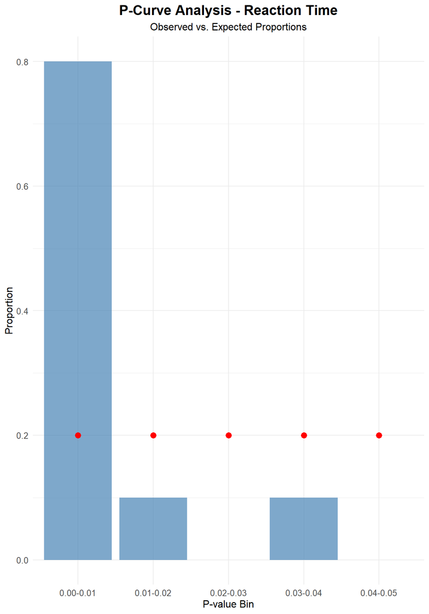

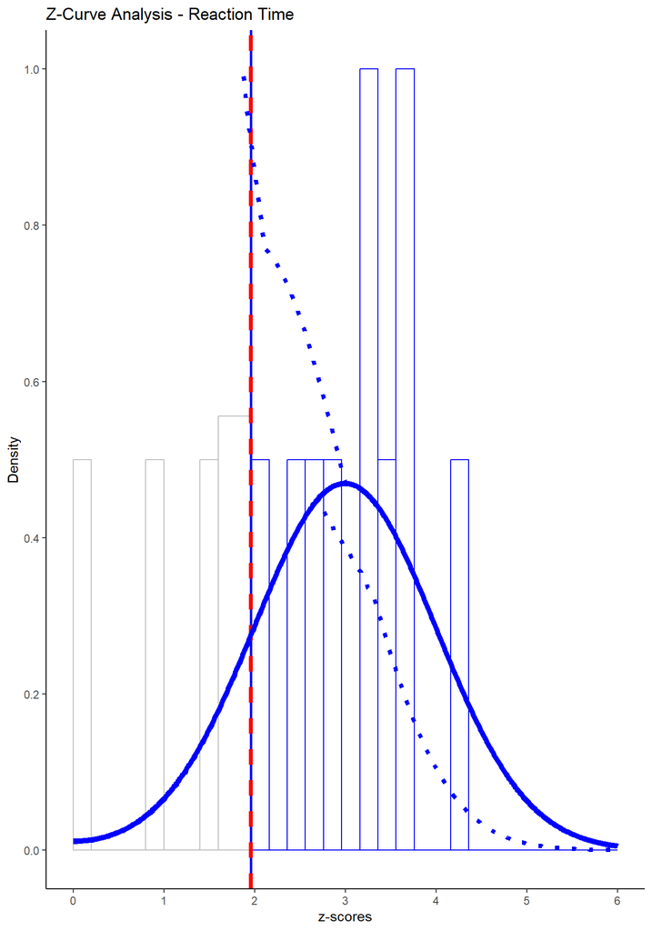

```r
#save_plot(acc_results, "ACC")
```